# Logistic Regression For Binary Classification

## Introduction

For students who have studied cell biology and biochemistry, logistic regression may already be familiar. It may also be known as a *sigmoidal curve*, *dose-response curve*, *4-parameter fit*, a *median lethal dose curve* (LD-50) or even an exponential growth curve given limited resources. However it can also be thought of a binary classifier which can toggle between off and on, zero or one.

Logistic regression derives it name from the similarity to linear regression, for reasons you will see below. In this circumstance it does not calculate a dependent variable $(y)$ as a regression is normally thought to do but instead Logistic Regression is used for classification between two states as follows.

$$f(x) = ~~ \left \{ \begin{matrix} 0 ~~for~~ x < 0 \\ 1 ~~for~~ x \geq 0 \end{matrix} \right.$$

In this simple form we can use the generation of a zero or one as a binary or logical value, hence logistic, zero indicating the absence of some quality or item and one indicating its presence.

The domain ($x$) of our logistic equation may be ($-\infty$ to $\infty$), but at the **decision boundary** of $x ~=$ 0 (for this example) our system changes from *zero*, absence, to *one*, the presence of a quality or item. In the Logistic/Sigmoidal Curve figure below, the **decision boundary** is denoted by the *red dotted line*.

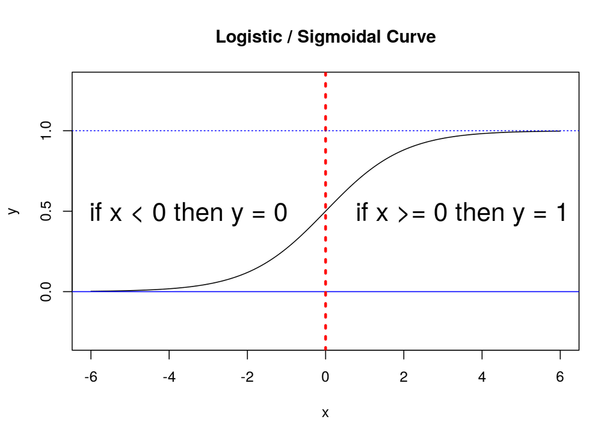

The logistic growth curve is commonly denoted by:

$$f(x) ~=~ \frac{M}{1 + Ae^{-r(x - x_0)}}$$

where $M$ is the curve’s maximum value, $r$ is the maximum growth rate (also called the Malthusian parameter[^1]), $x_0$ is the midpoint of the curve, $A$ is the number of times that the initial population must double to reach $M$.[^2]

In the specific case of *Logistic Regression for Binary Classification* where we have a probability between 0 and 1, $M$ and $A$ take on the value one.

Since the logistic equation is exponential it is easier to consider working with the formula in terms of the the odds or log odds. Odds are the probabilities of success over failure denoted as $\Large \frac{p}{1-p}$ or log odds as $\large ln \left (\frac{p}{1-p} \right )$.

In logistic regression we find that the log odds may be expressed as a set of linear equations in x. This is simply a transformation of exponential curve to make it linear. The set of linear equations is similar to the idea inherent in Linear Regression.

$$ln ~ \left ( \frac{Pr(y_i ~=~ 1|x_i)}{Pr(y_i ~=~ 0|x_i)} \right ) =~ \beta_0 + \beta_1 x_1 +~ ... ~+ \beta_{n} x_{n}$$

Substituting $p$ for $Pr(y_i ~=~ 1|x_i)$ and $1-p$ for $Pr(y_i ~=~ 0|x_i)$ we have:

$$ln \left( \frac {p}{1-p} \right) =~ \sum_i^{k} \beta_i x_i$$

Eliminate the natural log by taking the exponent on both sides:

$$\large \frac {p}{1-p} =~ exp \left ( \sum_i^{k} \beta_i x_i \right )$$

$$\large \frac {p}{1-p} =~ e^u ~~:~~ where ~~ u = \sum_i^{k} \beta_i x_i$$

Rearrange to solve for $\large p$ we find:

$$\large p(u) ~=~ \frac{e^u}{1 + e^u}$$

Take the derivative of both sides using quotient rule:

$$p'(u) ~=~ \frac {(e^u)(1 + e^u) - (e^u)(e^u)}{(1 + e^u)^2}$$

Simplify:

$$p'(u) ~=~ \frac {e^u}{(1 + e^u)^2}$$

Separate out to produce two fractions:

$$p'(u) ~=~ \left ( \frac {e^u}{1 + e^u} \right ) \cdot \left ( \frac{1}{1 + e^u} \right )$$

Substitute success and failure variables back into place.

$$p'(u) ~=~ p(u) \cdot ( 1 - p(u))$$
[^3]

```r
# Load Libraries
Libraries <- c("doMC", "knitr", "readr", "tidyverse", "caret")

for (p in Libraries) {  # Install Library if not present
    if (!require(p, character.only = TRUE)) { install.packages(p) }
    library(p, character.only = TRUE)
}
opts_chunk$set(cache = TRUE, warning = FALSE, message = FALSE)
```

```r
# Import data & data handling
c_m_TRANSFORMED <- read_csv("../00-data/02-aac_dpc_values/c_m_TRANSFORMED.csv",
                            col_types = cols(Class = col_factor(levels = c("0","1")),
                                             PID = col_skip(),
                                             TotalAA = col_skip()))
```

```r
# Partition data into training and testing sets
set.seed(1000)
index <- createDataPartition(c_m_TRANSFORMED$Class, p = 0.8, list = FALSE)

training_set.1 <- c_m_TRANSFORMED[index, ]
#test_set.1     <- c_m_TRANSFORMED[-index,] # NOT needed since this run is not kept
#Class_test <- as.factor(test_set.1$Class) # NOT needed since this run is not kept
```

The `test.set.1` and `Class.test` data sets are not produced due to the fact that the Logit run with 20 features was not deamed useful. The reason for it dismissal was that is contained features which were extraneous.

## Logit Training #1 using 20 Features

```r
set.seed(1000)
registerDoMC(cores = 3)  # Start multi-processor mode
start_time <- Sys.time() # Start timer

# Create model, 10X fold CV repeated 5X
tcontrol <- trainControl(method = "repeatedcv",
                         number = 10,
                         repeats = 5)

model_obj.1 <- train(Class ~ .,
                     data = training_set.1,
                     trControl = tcontrol,
                     method = "glm",
                     family = "binomial")

end_time <- Sys.time()  # End timer
end_time - start_time   # Display time
```

```
## Time difference of 1.591719 secs
```

```r
registerDoSEQ() # Stop multi-processor mode
```

## Logit Results #1

```r
summary(model_obj.1)
```

```
##
## Call:
## NULL
##
## Deviance Residuals:
##     Min       1Q   Median       3Q      Max
## -5.9372  -0.2835  -0.0194   0.0516   3.6884
##
## Coefficients:
##             Estimate Std. Error z value Pr(>|z|)
## (Intercept)   8.0525     9.2156   0.874 0.382234
## A             5.0438     9.6899   0.521 0.602699
## C           -14.2228     2.6949  -5.278 1.31e-07 ***
## D           -36.2676     8.0845  -4.486 7.25e-06 ***
## E            27.6016    11.1292   2.480 0.013135 *
## F             5.6174     5.2654   1.067 0.286034
## G           -22.1970    10.3043  -2.154 0.031229 *
## H            90.1101    12.1105   7.441 1.00e-13 ***
## I            -5.9795     4.3945  -1.361 0.173610
## K            -2.8961     9.8468  -0.294 0.768669
## L            -3.7417     9.2217  -0.406 0.684926
## M            -0.1427    12.0747  -0.012 0.990570
## N             3.3478     9.6749   0.346 0.729319
## P           -39.7466    11.1010  -3.580 0.000343 ***
## Q            -5.6804    11.2516  -0.505 0.613664
## R           -83.6045    11.8104  -7.079 1.45e-12 ***
## S            -9.9745    10.0872  -0.989 0.322750
## T           -36.5980     9.2791  -3.944 8.01e-05 ***
## V            16.3411     9.7859   1.670 0.094946 .
## W             9.0169    13.8870   0.649 0.516141
## Y           -31.9282    11.1167  -2.872 0.004078 **
## ---
## Signif. codes:  0 '***' 0.001 '**' 0.01 '*' 0.05 '.' 0.1 ' ' 1
##
## (Dispersion parameter for binomial family taken to be 1)
##
##     Null deviance: 2593.68  on 1872  degrees of freedom
## Residual deviance:  657.72  on 1852  degrees of freedom
## AIC: 699.72
##
## Number of Fisher Scoring iterations: 8
```

The Akaike information criterion (AIC) for model #1 is: 699.72. This will be used later to compare the models generated to rate their ability to best utilize the features. - The list of probabilities for the estimates leaves us with only **9 important features** to try re-modeling, R, H, P, C, E, Y, T, D, G.

## Logit Training #2 using 9 Features

- Using **ONLY** features: (R, H, P, C, E, Y, T, D, G)

```r
# Data import & handling
c_m_9aa <- read_csv("../00-data/02-aac_dpc_values/c_m_TRANSFORMED.csv",
                     col_types = cols(Class = col_factor(levels = c("0","1")),
                                      A = col_skip(),
                                      F = col_skip(),
                                      I = col_skip(),
                                      K = col_skip(),
                                      L = col_skip(),
                                      M = col_skip(),
                                      N = col_skip(),
                                      PID = col_skip(),
                                      Q = col_skip(),
                                      V = col_skip(),
                                      S = col_skip(),
                                      TotalAA = col_skip(),
                                      W = col_skip()))
```

```r
# Partition data into training and testing sets
set.seed(1000)
index <- createDataPartition(c_m_9aa$Class, p = 0.8, list = FALSE)

training_set.2 <- c_m_9aa[ index, ]
test_set.2     <- c_m_9aa[-index, ]

Class_test.2 <- as.factor(test_set.2$Class)
```

### Logit Training #2 with 9 Features

```r
set.seed(1000)
registerDoMC(cores = 3)  # Start multi-core
start_time <- Sys.time() # Start timer

# Create model, 10X fold CV repeated 5X
fitControl <- trainControl(method = "repeatedcv",
                           number = 10,
                           repeats = 5,
                           savePredictions = "final") # IMPORTANT: Saves predictions

model_obj.2 <- train(Class ~ .,
                     data = training_set.2,
                     trControl = fitControl,
                     method = "glm",
                     family = "binomial")

end_time <- Sys.time()   # End timer
end_time - start_time    # Display time
```

```
## Time difference of 1.419131 secs
```

```r
registerDoSEQ()          # Stop multi-core
```

## Logit Summary #2

```r
summary(model_obj.2)
```

```
##
## Call:
## NULL
##
## Deviance Residuals:
##     Min       1Q   Median       3Q      Max
## -6.2083  -0.2984  -0.0204   0.0601   3.5666
##
## Coefficients:
##             Estimate Std. Error z value Pr(>|z|)
## (Intercept)    8.306      1.007   8.245  < 2e-16 ***
## C            -14.755      1.908  -7.733 1.05e-14 ***
## D            -31.411      4.949  -6.347 2.20e-10 ***
## E             21.932      5.092   4.307 1.66e-05 ***
## G            -23.259      5.071  -4.587 4.49e-06 ***
## H             94.580      8.431  11.218  < 2e-16 ***
## P            -29.394      6.264  -4.692 2.70e-06 ***
## R            -82.809      6.363 -13.015  < 2e-16 ***
## T            -40.915      5.624  -7.275 3.45e-13 ***
## Y            -37.860      6.291  -6.018 1.77e-09 ***
## ---
## Signif. codes:  0 '***' 0.001 '**' 0.01 '*' 0.05 '.' 0.1 ' ' 1
##
## (Dispersion parameter for binomial family taken to be 1)
##
##     Null deviance: 2593.68  on 1872  degrees of freedom
## Residual deviance:  688.96  on 1863  degrees of freedom
## AIC: 708.96
##
## Number of Fisher Scoring iterations: 8
```

## Logit Confusion Matrix #2

```r
Predicted_test_vals <- predict(model_obj.2, test_set.2[, -1])

confusionMatrix(Predicted_test_vals, Class_test.2, positive = "1")
```

```
## Confusion Matrix and Statistics
##
##           Reference
## Prediction   0   1
##          0 235  18
##          1   8 206
##
##                Accuracy : 0.9443
##                  95% CI : (0.9195, 0.9633)
##     No Information Rate : 0.5203
##     P-Value [Acc > NIR] : < 2e-16
##
##                   Kappa : 0.8883
##
##  Mcnemar's Test P-Value : 0.07756
##
##             Sensitivity : 0.9196
##             Specificity : 0.9671
##          Pos Pred Value : 0.9626
##          Neg Pred Value : 0.9289
##              Prevalence : 0.4797
##          Detection Rate : 0.4411
##    Detection Prevalence : 0.4582
##       Balanced Accuracy : 0.9434
##
##        'Positive' Class : 1
##
```

- The Akaike information criterion (AIC) for model #2 is: 708.96. This will be used later to compare the models generated to rate their ability to best utilize the features.
- The number of unique false-positives and false-negatives are 26.

## Obtain List of False Positives & False Negatives

```r
fp_fn_logit <- model_obj.2 %>% pluck("pred") %>% dplyr::filter(obs != pred)

# Write CSV in R
write.table(fp_fn_logit,
            file = "../00-data/03-ml_results/fp_fn_logit.csv",
            row.names = FALSE,
            na = "",
            col.names = TRUE,
            sep = ",")

nrow(fp_fn_logit) ## NOTE: NOT UNIQUE NOR SORTED
```

```
## [1] 536
```

```
536 proteins listed although they are NOT UNIQUE NOR SORTED.
```

## Conclusion

Logit is easy to implement and understand and can be used for parameter importance measurements.

Akaike Information Criterion:

Where $ln (\widehat{L})$ is the log likelihood, $K$ is the number of parameters.

| Model # | Features | AIC |
| --- | --- | --- |
| 1 | 20 | 699.72 |
| 2 | 9 | 708.96 |

Logit is a common machine learning method. It is easy to understand and explain. This supervised binary classification method is very useful for determining the importance of the features which can be applied. As we saw in Model#1 there were 11 features which had probabilities of the estimates used above the 5% threshold cut-off. In Model#2 only 9 features were used to describe the model and the AIC increased by 9.24.

The nine features which best described the logistic regression model were R, H, P, C, E, Y, T, D, G. If we compare this to the Boruta test carried out in the EDA we find the overlap interesting.

**Test Model / Order of Importance (From Left To Right)**

| Test Model |  |  |  |  |  |  |  |  |  |  |  |  |  |  |  |  |  |  |  |  |
| --- | --- | --- | --- | --- | --- | --- | --- | --- | --- | --- | --- | --- | --- | --- | --- | --- | --- | --- | --- | --- |
| Order | 1 | 2 | 3 | 4 | 5 | 6 | 7 | 8 | 9 | 10 | 11 | 12 | 13 | 14 | 15 | 16 | 17 | 18 | 19 | 20 |
| Boruta | R | H | P | K | C | E | Y | T | S | A | V | U | I | F | D | G | N | L | M | Q |
| Logit | R | H | P | . | C | E | Y | T | . | . | . | . | . | . | D | G | . | . | . | . |

The first 7 out of 8 amino acid features are seen in the proper order as described by the Boruta Random Forest model. This is confirmation that Logit can pick up the importance of features similar to Boruta.

Logit produced 536 proteins which are false-negatives or false-positives. It should be noted that the 536 are NOT UNIQUE NOR SORTED. The number of FN/FP from the confusion matrix is 26. These proteins will be investigated further in the Outliers section which compares these FN/FP proteins to the PCA outliers.

[^1]: https://en.wikipedia.org/wiki/Malthusian_growth_model
[^2]: https://en.wikipedia.org/wiki/Logistic_function
[^3]: http://juangabrielgomila.com/en/logistic-regression-derivation/